# Exploratory analysis

Haoran Hu

2019-3-26

## Analysis

### Load the data

```r
fifa = read_csv("..\\Data\\CompleteDataset.csv")
```

### Set the seed

```r
set.seed(3)
```

### data cleaning

Values for some players were recorded in “M” unit, and value for other players were recorded in “K” unit. So I first change them into the same scale.

```r
calc_expression = function(fmula) {
    eval(parse(text = fmula))
}

data = fifa %>%
    janitor::clean_names() %>%
    select(-c(x1, name, photo, flag, club_logo, wage, overall, id)) %>%
    #mutate(value = readr::parse_number(value))
    mutate(value = str_replace(value, "K", "/ 1000"),
           value = str_replace(value, "M", ""),
           value = str_replace(value, "€", "")) %>%
    mutate(value = map(value, calc_expression),
           value = as.numeric(value))
```

Next, I will transform variables into suitable data type.

```r
trans2int_cols = c(7:40)
trans2fct_cols = c(2, 4)
data[trans2int_cols] = map(data[trans2int_cols], as.integer)
data[trans2fct_cols] = map(data[trans2fct_cols], as.factor)
```

Variables that are important to all soccer players:

- `age`: (int)age of players
- `nationality`: (fct)nationality of players
- `potential`: (int)score of players’ potential
- `club`: (fct)club of players
- `special`: (int)aggregated score of players’ several special abilities( important abilities for all soccer players)
- `acceleration`: (int)score of players’ acceleration ability(an important ability for all soccer players)
- `aggression`: (int)score evaluating players’ level of aggression(important for all soccer players)
- `agility`: (int)score of players’ agility(an important ability for all soccer players)
- `balance`: (int)score of players’ balancing ability(an important ability for all soccer players)
- `ball control`: (int)score of players’ ball control ability(an important ability for all soccer players)
- `composure`: (int)score of players’ self-possession ability(an important ability for all soccer players)
- `curve`: (int)score of players’ curve skill(an important skill for all soccer players)
- `dribble`: (int)score of players’ dribbling skill(an important skill for all soccer players)
- `free_kick_accuracy`: (int)score of players’ free-kicking skill(an important skill for all soccer players)
- `interceptions`: (int)score of players’ interceptions(an important ability for all soccer players)
- `jumping`: (int)score of players’ jumping ability(an important ability for all soccer players)
- `long_passing`: (int)score of players’ long passing ability(an important ability for all soccer players)
- `penalty`: (int)score of players’ penalty skill(an important skill for all soccer players)
- `positioning`: (int)score of players’ positioning skill(an important skill for soccer players except goal keepers)
- `reactions`: (int)score of players’ reaction speed(important for soccer players except goal keepers)
- `short_passing`: (int)score of players’ short passing skill(an attacking skill, important for soccer players except goal keepers)
- `shot_power`: (int)score of players’ shot power(important for soccer players except goal keepers)
- `sprint_speed`: (int)score of players’ shot power(important for all soccer players)
- `stamina`: (int)score of players’ stamina(important for all soccer players)
- `strength`: (int)score of players’ strength(important for all soccer players)
- `vision`: (int)score of players’ vision(important for all soccer players)
- `sliding_tackle`:(int)score of players’ sliding tackle skill(an defending skill, but important for all soccer players)
- `standing_tackle`:(int)score of players’ standing tackle skill(an defending skill, but important for all soccer players)

Variables on goal-keeping skills:

- `gk_diving`: (int)score of goal keepers’ diving skill(an important skill for goal keepers)
- `gk_handling`: (int)score of goal keepers’ handling skill(an important skill for goal keepers)
- `gk_kicking`: (int)score of goal keepers’ kicking skill(an important skill for goal keepers)
- `gk_positioning`: (int)score of goal keepers’ positioning skill(an important skill for goal keepers)
- `gk_reflexes`: (int)score of goal keepers’ reflex speed(important for goal keepers)

Variables on attacking skills:

- `crossing`: (int)score of players’ crossing skill(an attacking skill, important for soccer players except goal keepers, especially important for forward players)
- `finishing`: (int)score of players’ finishing skill(an attacking skill, important for soccer players except goal keepers, especially important for forward players)
- `long_shots`: (int)score of players’ long shot skill(an attacking skill, important for soccer players except goal keepers, especially important for forward players)
- `heading`: (int)score of players’ heading skill(an attacking skill, important for soccer players except goal keepers)
- `volleys`: (int)score of players’ volleying skill(an attacking skill, important for soccer players except goal keepers)

Variables on defending skills:

- `marking`: (int)score of players’ marking skill(an defending skill, important for soccer players except goal keepers)

Outcome:

- `value`: (num)market value of players

Other:

- `preferred_possitions`: (chr)indicates players’ preferred positions

Each of the other variables in the dataset evaluates players’ ability when playing at a specific position.

In the next chunk, I will:

- seperate the column `preferred_positions` into multiple columns(`pos1`, `pos2`, `pos3`, `pos4`), so that each column indicates only one position.
- create a new variable `single_pos` indicating if a player’s have only one preferred position or not. If YES, `multi_pos` = TRUE. Otherwise, `multi_pos` = FALSE.
- create a new variable `max_pos_score`, which shows the maximum position score of a player. Goal keepers’ maximum position score will be set to 0, since in the original dataset, their position scores are all NA’s, and their goal keeping skills are indicated by other variables.
- create a new variable `best_pos`, which shows the position where the player’s position score gets the maximum. Goal keepers’ best positions will be directly specified as “gk”.

```r
pos_data = data %>% #a temporary data frame used to get the maximum position score and the position where the player's position score gets the maximum
    select(cam:st) %>%
    select(-preferred_positions, everything()) %>%
    #mutate(., max_pos_score = purrr::pmap(.[, 1:(ncol(.) - 1)], max)) %>%
    mutate(., max_pos_score = apply(.[, 1:(ncol(.) - 1)], 1, max)) %>% #get the maximum position score
    mutate(., best_pos = colnames(.)[max.col(.[, 1:(ncol(.) - 2)],ties.method = "first")]) %>%  #get the position where the player's position score gets the maximum
    select(preferred_positions, max_pos_score, best_pos)

gk_pos_score = function(Pos, scor){
    if (Pos == "GK") {
        scor = 0
    }
    else
        scor = scor
    scor
}#a function to set GKs' position scores to be 0

gk_pos = function(Pos, pos_out){
    if (Pos == "GK") {
        pos_out = "gk"
    }
    else
        pos_out = pos_out
    pos_out
}#a function to set GKs' best position to be "gk"

pos_data = pos_data %>%
    mutate(max_pos_score = map2(preferred_positions, max_pos_score, gk_pos_score),
           best_pos = map2(preferred_positions, best_pos, gk_pos))


data = data %>%
    mutate(max_pos_score = as.integer(pos_data$max_pos_score),
           best_pos = as.character(pos_data$best_pos)) %>%
    mutate(best_pos = as.factor(best_pos)) %>%
    separate(preferred_positions, c("pos1", "pos2", "pos3", "pos4"), sep = " ", remove = TRUE) %>%
    mutate(single_pos = map(pos2, is.na)) %>%
    mutate(single_pos = unlist(single_pos))
```

Since soccer players have relatively stable positions, their values should be mainly depend on their performance at their preferred position. Then, it’s reasonable to put more emphasis on their scores at the best position for each of them.

In the following chunk, I will:

- check missing data in each observation in the dataset. Since a lot of NA’s are caused by missing position score data of goal keepers, and These NA’s do not matter, I will amalyze goal-keeper data and non goal-keeper data seperately.

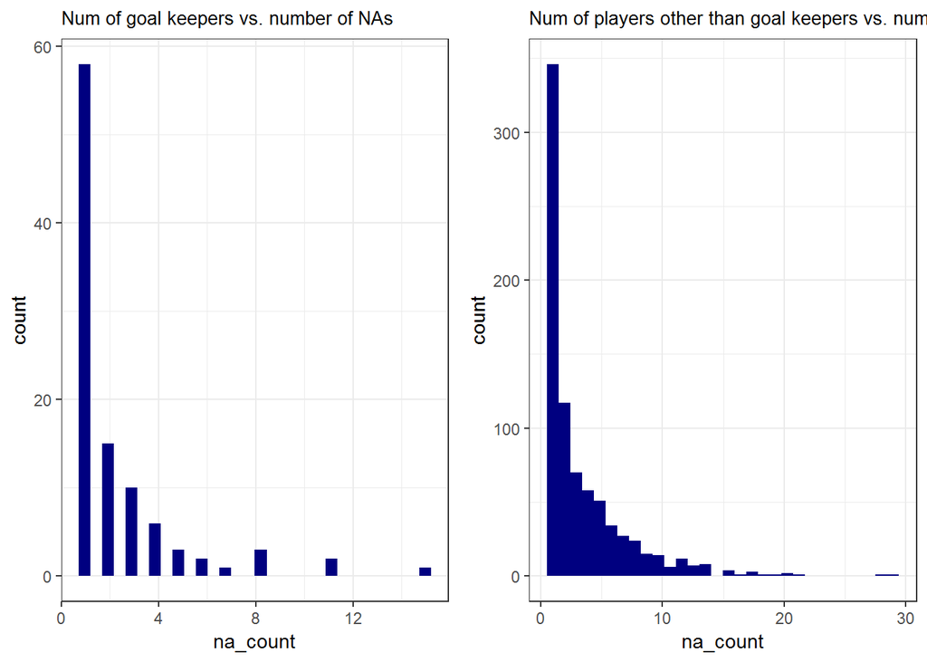

```r
data_gk = data %>%
    filter(best_pos == "gk") %>%
    select(-(cam:st)) %>%
    mutate(., na_count = apply(., 1, function(x) sum(is.na(x))))#the na_count shows number of NA's that are not caused by missing position score data in each observation

data_other = data %>%
    filter(best_pos != "gk") %>%
    select(-(pos1:pos4)) %>%
    mutate(., na_count = apply(., 1, function(x) sum(is.na(x))))#the na_count shows number of NA's in each observation

P1 = data_gk %>%
    filter(na_count > 0) %>%
    ggplot(aes(x = na_count)) + geom_histogram(fill = "navy") + theme_bw() + labs(title = "Num of goal keepers vs. number of NAs") + theme(plot.title = element_text(size = 10))

P2 = data_other %>%
    filter(na_count > 0) %>%
    ggplot(aes(x = na_count)) + geom_histogram(fill = "navy") + theme_bw() + labs(title = "Num of players other than goal keepers vs. number of NAs") + theme(plot.title = element_text(size = 10))

P1 + P2
```

From the plot, it seems to be reasonable to drop observations that have more than 5 missing values. In the next chunk, I will:

- drop observations that have more than 5 missing values
- check number of NA’s in each variable

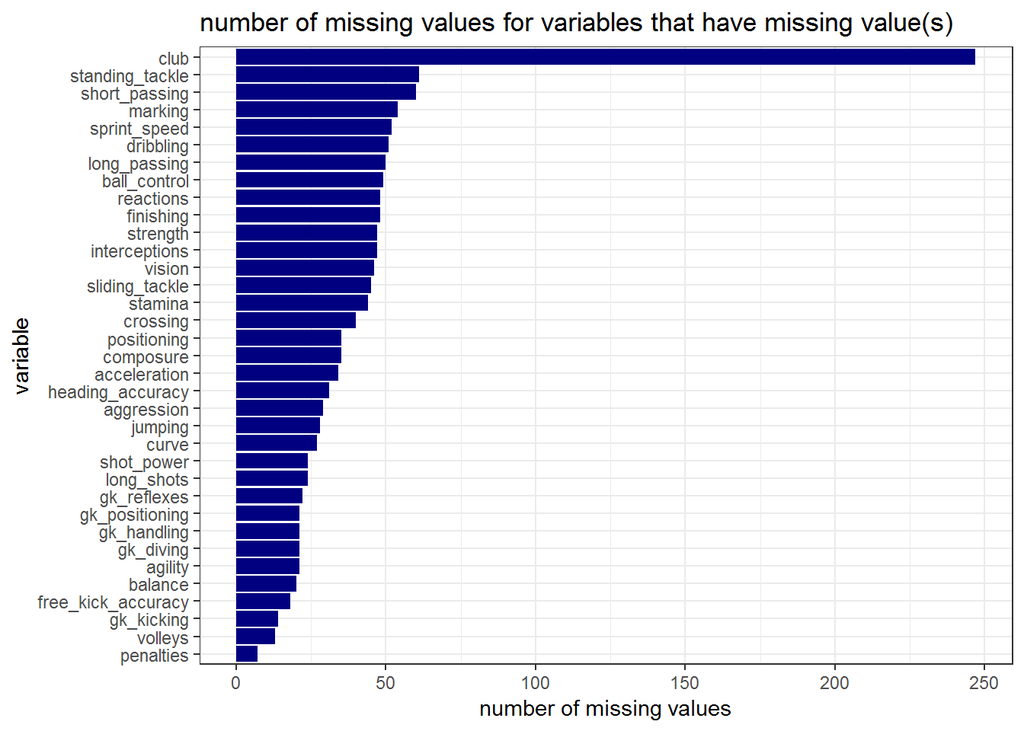

```r
data_gk = data_gk %>%
    filter(na_count <= 5)

data_other = data_other %>%
    filter(na_count <= 5)

na_gk = colSums(is.na(data_gk)) %>%
    as.list() %>%
    as.data.frame() %>%
    select(-na_count) %>%
    gather(age:single_pos, key = "variable", value = "num_of_na")

na_other = colSums(is.na(data_other)) %>%
    as.list() %>%
    as.data.frame() %>%
    select(-na_count) %>%
    gather(age:single_pos, key = "variable", value = "num_of_na")

na_all = merge(na_gk, na_other, by = "variable", all = TRUE) %>%
    mutate(., num_of_na.x = replace_na(.$num_of_na.x, 0)) %>%
    mutate(., num_of_na = .$num_of_na.x + .$num_of_na.y)


na_all %>%
    filter(num_of_na > 0) %>%
    mutate(variable = fct_reorder(variable, num_of_na)) %>%
    ggplot(aes(x = variable, y = num_of_na)) +
  geom_col(fill = "navy") +
  theme(legend.position = "bottom") +
  labs(title = "number of missing values for variables that have missing value(s)", y = "number of missing values") +
  coord_flip() + theme(axis.text.x = element_text(face = "plain", color = "black", size = 8)) + theme_bw()
```

In total, 35 variables have missing values. The “club” variable has the largest number of missing values(247 missing values). Note that all the players that have missing “club” values have market values = 0. This actually means they do not belong to any club for the time being. It seems reasonable to create a new category for the missing clubs, i.e., substitute NA’s in “club” column with the word “none”. Each of the other variables that have missing values has at most 61 missing values. Compared to the sample size, that’s not a big loss of data, and thus all the variables can be kept in the model. The missing values of a varible will be replaced by the average observed value of the variable.

In the next chunk, I will:

```r
#get the names of variables that have missing values, except for "club"
vbls_replace_NA = na_all %>%
    filter(num_of_na > 0 & variable != "club")

#for variables(except for "club") that have missing values, replace NA's with mean
for (i in 1:34) {
    vbl_name = vbls_replace_NA$variable[i]
    #col_num = which(colnames(data_gk) == vbl_name) %>%
        #as.numeric()
       vec = data_gk[vbl_name] %>%
        unlist() %>%
        unname()
       #data_gk[is.na(data_gk[,col_num]), col_num] = round(mean(vec, na.rm = TRUE))
       data_gk[is.na(data_gk[,vbl_name]), vbl_name] = round(mean(vec, na.rm = TRUE))

       vec = data_other[vbl_name] %>%
        unlist() %>%
        unname()
       data_other[is.na(data_other[,vbl_name]), vbl_name] = round(mean(vec, na.rm = TRUE))
}


data_gk = data_gk %>%
    mutate(club = forcats::fct_explicit_na(club, na_level = "none"))
data_other = data_other %>%
    mutate(club = forcats::fct_explicit_na(club, na_level = "none"))

sum(is.na(data_gk)) #=0
```

```
## [1] 0
```

```r
sum(is.na(data_other)) #=0
```

```
## [1] 0
```

In the next chunk, I will:

- bind the rows of goal keepers’ data and non goal keepers’ data.

```r
data = bind_rows(data_gk, data_other) %>%
    select(-na_count)

rm(data_gk)
rm(data_other)
```

## Tables for descriptive statistics

```r
descrip_list = data %>%
  dplyr::select(-max_pos_score, -(cam:st)) %>% #max_pos_score need to be analyzed seperately, since their values are equal to 0 for all goal keepers
  skimr::skim_to_list()

descrip_list_maxpos = data %>%
    filter(max_pos_score > 0) %>%
    select(max_pos_score, cam:st) %>%
    skimr::skim_to_list() #analyzed max_pos_score seperately

descrip_list[[1]] %>%
    select(variable, n_unique) %>%
    dplyr::rename("unique levels" = n_unique) %>%
    knitr::kable(caption = "Factor variables")
```

Factor variables

| variable | unique levels |
| --- | --- |
| best_pos | 11 |
| club | 648 |
| nationality | 165 |

```r
bind_rows(descrip_list[[2]] , descrip_list_maxpos[[1]]) %>% #combine with max_pos_score
    mutate(variable = recode(variable, x = 'max_pos_score')) %>%
    dplyr::select(variable,
                Min = p0,
                `1st Q` = p25,
                Mean = mean,
                Median = p50,
                `3rd Q` = p75,
                Max = p100,
                `Std Dev` = sd) %>%
  knitr::kable(digits = 3)
```

| variable | Min | 1st Q | Mean | Median | 3rd Q | Max | Std Dev |
| --- | --- | --- | --- | --- | --- | --- | --- |
| age | 16 | 21 | 25.16 | 25 | 28 | 47 | 4.62 |
| potential | 46 | 67 | 71.17 | 71 | 75 | 94 | 6.1 |
| special | 728 | 1448 | 1593.51 | 1633 | 1785 | 2291 | 272.53 |
| max_pos_score | 45 | 62 | 65.95 | 66 | 71 | 92 | 6.78 |

```r
tibble(levels = c("TRUE", "FALSE"),
       proportion = c(0.46, 0.54)) %>%
    knitr::kable(caption = "Levels of single_pos variable(logi)")
```

Levels of single_pos variable(logi)

| levels | proportion |
| --- | --- |
| TRUE | 0.46 |
| FALSE | 0.54 |

```r
bind_rows(descrip_list[[4]], descrip_list_maxpos[[2]])  %>%
      dplyr::select(variable,
                Min = p0,
                `1st Q` = p25,
                Mean = mean,
                Median = p50,
                `3rd Q` = p75,
                Max = p100,
                `Std Dev` = sd) %>%
    knitr::kable(caption = "Integer variables")
```

Integer variables

| variable | Min | 1st Q | Mean | Median | 3rd Q | Max | Std Dev |
| --- | --- | --- | --- | --- | --- | --- | --- |
| acceleration | 11 | 56 | 64.55 | 67 | 75 | 96 | 14.91 |
| aggression | 11 | 43 | 55.8 | 59 | 69 | 96 | 17.48 |
| agility | 14 | 55 | 63.3 | 65 | 74 | 96 | 14.8 |
| balance | 11 | 56 | 63.79 | 66 | 74 | 96 | 14.11 |
| ball_control | 8 | 53 | 58.07 | 63 | 69 | 95 | 16.82 |
| composure | 5 | 51 | 57.87 | 60 | 67 | 96 | 12.93 |
| crossing | 5 | 38 | 49.73 | 54 | 64 | 91 | 18.46 |
| curve | 6 | 34 | 47.25 | 48 | 62 | 92 | 18.46 |
| dribbling | 2 | 48 | 55.01 | 60 | 68 | 97 | 19 |
| finishing | 2 | 29 | 45.22 | 48 | 61 | 95 | 19.46 |
| free_kick_accuracy | 4 | 31 | 43.13 | 42 | 57 | 93 | 17.57 |
| gk_diving | 1 | 8 | 16.77 | 11 | 14 | 91 | 17.82 |
| gk_handling | 1 | 8 | 16.54 | 11 | 14 | 91 | 17.05 |
| gk_kicking | 1 | 8 | 16.42 | 11 | 14 | 95 | 16.64 |
| gk_positioning | 1 | 8 | 16.53 | 11 | 14 | 91 | 17.16 |
| gk_reflexes | 1 | 8 | 16.9 | 11 | 14 | 90 | 18.11 |
| heading_accuracy | 4 | 45 | 52.31 | 56 | 64 | 94 | 17.42 |
| interceptions | 4 | 26 | 46.53 | 51 | 64 | 92 | 20.68 |
| jumping | 15 | 58 | 64.88 | 66 | 73 | 95 | 11.88 |
| long_passing | 7 | 42 | 52.41 | 56 | 64 | 93 | 15.53 |
| long_shots | 3 | 32 | 47.17 | 51 | 62 | 92 | 19.28 |
| marking | 4 | 22 | 44.07 | 48 | 63 | 92 | 21.56 |
| penalties | 5 | 39 | 48.96 | 50 | 61 | 92 | 15.83 |
| positioning | 2 | 38 | 49.59 | 54 | 64 | 95 | 19.44 |
| reactions | 28 | 55 | 61.9 | 62 | 68 | 96 | 9.16 |
| short_passing | 10 | 53 | 58.26 | 62 | 68 | 92 | 14.93 |
| shot_power | 3 | 46 | 55.62 | 59 | 69 | 94 | 17.4 |
| sliding_tackle | 4 | 24 | 45.53 | 51 | 64 | 91 | 21.47 |
| sprint_speed | 11 | 57 | 64.77 | 67 | 75 | 96 | 14.63 |
| stamina | 12 | 56 | 63.21 | 66 | 74 | 95 | 15.94 |
| standing_tackle | 4 | 26 | 47.4 | 54 | 66 | 92 | 21.82 |
| strength | 20 | 58 | 65.29 | 66 | 74 | 98 | 12.61 |
| value | 0 | 0.3 | 2.38 | 0.68 | 2.1 | 123 | 5.36 |
| vision | 10 | 43 | 52.97 | 54 | 64 | 94 | 14.38 |
| volleys | 4 | 30 | 43.18 | 44 | 57 | 91 | 17.74 |
| cam | 27 | 53 | 59.24 | 60 | 66 | 92 | 9.89 |
| cb | 25 | 45 | 55.56 | 57 | 65 | 87 | 12.2 |
| cdm | 26 | 49 | 56.87 | 58 | 65 | 85 | 10.32 |
| cf | 27 | 53 | 59.01 | 60 | 66 | 92 | 9.93 |
| cm | 30 | 53 | 58.5 | 59 | 65 | 87 | 8.9 |
| lam | 27 | 53 | 59.24 | 60 | 66 | 92 | 9.89 |
| lb | 30 | 50 | 56.98 | 58 | 64 | 84 | 9.8 |
| lcb | 25 | 45 | 55.56 | 57 | 65 | 87 | 12.2 |
| lcm | 30 | 53 | 58.5 | 59 | 65 | 87 | 8.9 |
| ldm | 26 | 49 | 56.87 | 58 | 65 | 85 | 10.32 |
| lf | 27 | 53 | 59.01 | 60 | 66 | 92 | 9.93 |
| lm | 28 | 54 | 60.04 | 61 | 67 | 90 | 9.35 |
| ls | 31 | 52 | 58.19 | 59 | 65 | 92 | 9.18 |
| lw | 26 | 53 | 59.34 | 60 | 66 | 91 | 9.98 |
| lwb | 31 | 51 | 57.7 | 58 | 64 | 84 | 9.15 |
| ram | 27 | 53 | 59.24 | 60 | 66 | 92 | 9.89 |
| rb | 30 | 50 | 56.98 | 58 | 64 | 84 | 9.8 |
| rcb | 25 | 45 | 55.56 | 57 | 65 | 87 | 12.2 |
| rcm | 30 | 53 | 58.5 | 59 | 65 | 87 | 8.9 |
| rdm | 26 | 49 | 56.87 | 58 | 65 | 85 | 10.32 |
| rf | 27 | 53 | 59.01 | 60 | 66 | 92 | 9.93 |
| rm | 28 | 54 | 60.04 | 61 | 67 | 90 | 9.35 |
| rs | 31 | 52 | 58.19 | 59 | 65 | 92 | 9.18 |
| rw | 26 | 53 | 59.34 | 60 | 66 | 91 | 9.98 |
| rwb | 31 | 51 | 57.7 | 58 | 64 | 84 | 9.15 |
| st | 31 | 52 | 58.19 | 59 | 65 | 92 | 9.18 |

# Figures for descriptive statistics

## For the outcome(value)

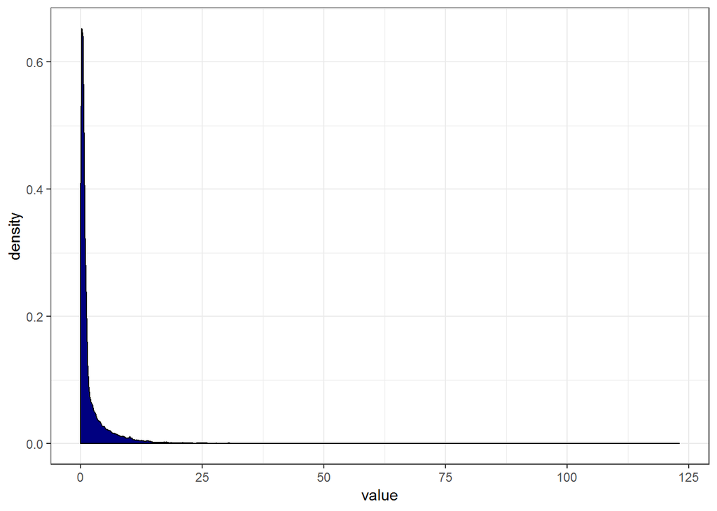

```r
data %>%
    ggplot(aes(x = value)) + geom_density(fill = "navy") + theme_bw()
```

The outcome data is skewed, so I will transform it. New_value = Old_value^(1/4)

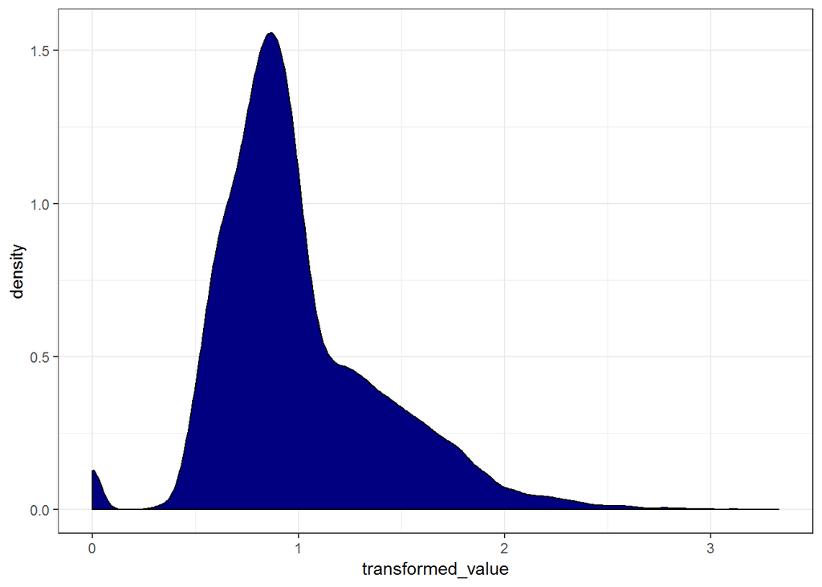

```r
#The effect of log transformation is not ideal
#data = data %>%
#   mutate(value = log(value + 2)

data = data %>%
    mutate(value = value^(1/4)) %>%
    rename("transformed_value" = value)

data %>%
    ggplot(aes(x = transformed_value)) + geom_density(fill = "navy") + theme_bw()
```

## Check the distribution for each numeric/integer predictor

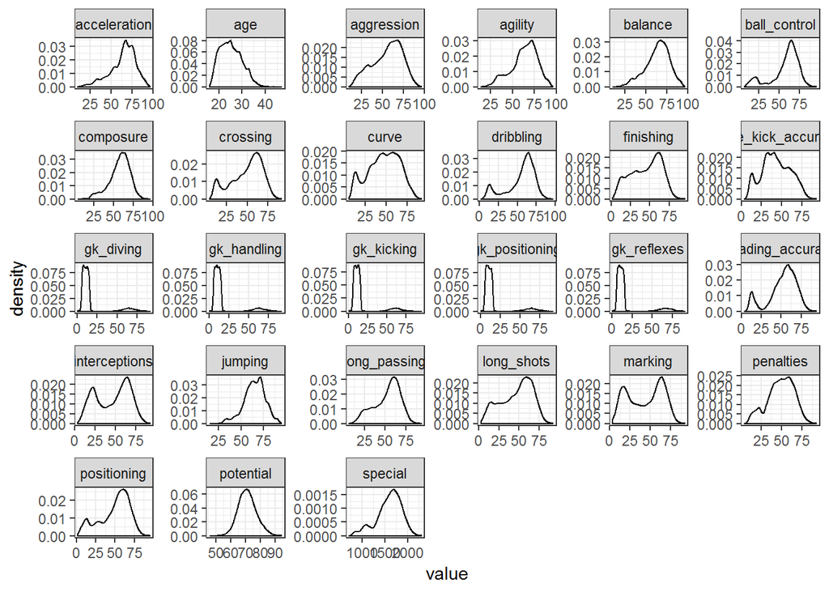

```r
data[,1:30] %>%
    select(-transformed_value) %>%
  keep(is.numeric) %>%                     # Keep only numeric columns
  gather() %>%                             # Convert to key-value pairs
  ggplot(aes(value)) +                     # Plot the values
    facet_wrap(~ key, scales = "free") +   # In separate panels
    geom_density() +
    theme_bw()
```

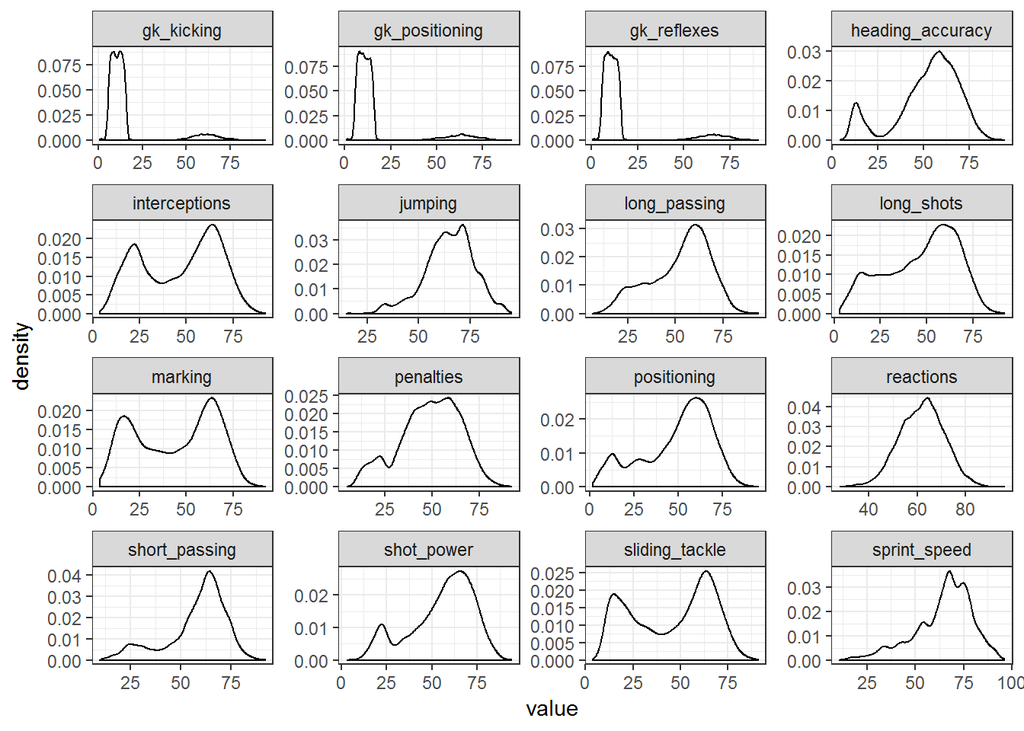

```r
data[,20:35] %>%
  keep(is.numeric) %>%                     # Keep only numeric columns
  gather() %>%                             # Convert to key-value pairs
  ggplot(aes(value)) +                     # Plot the values
    facet_wrap(~ key, scales = "free") +   # In separate panels
    geom_density()+
    theme_bw()
```

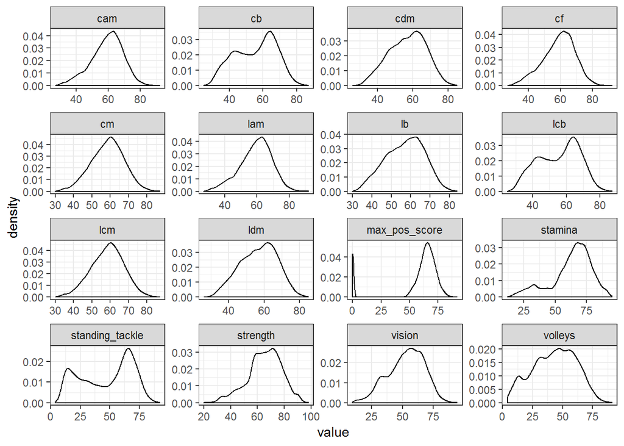

```r
data[,36:53] %>%
  keep(is.numeric) %>%                     # Keep only numeric columns
  gather() %>%                             # Convert to key-value pairs
  ggplot(aes(value)) +                     # Plot the values
    facet_wrap(~ key, scales = "free") +   # In separate panels
    geom_density()  +
    theme_bw()
```

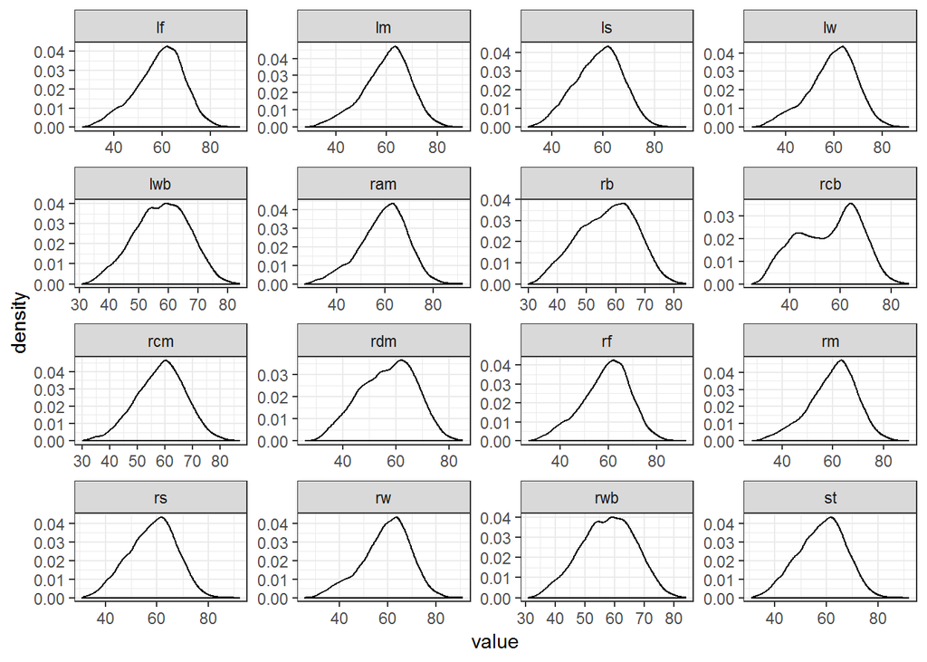

```r
data[,54:69] %>%
  keep(is.numeric) %>%                     # Keep only numeric columns
  gather() %>%                             # Convert to key-value pairs
  ggplot(aes(value)) +                     # Plot the values
    facet_wrap(~ key, scales = "free") +   # In separate panels
    geom_density()  +
    theme_bw()
```

There seems not to be any data error. The variable `max_pos_score` has unusually large amount of 0 zero values because I set it to be 0 for goal keepers. For the variables whose density plots have two peaks, the smaller peaks are generally caused by goal keepers, and the larger peaks are generally caused by non-goal keepers.

## plot for variables

### for factor variables

- best_pos

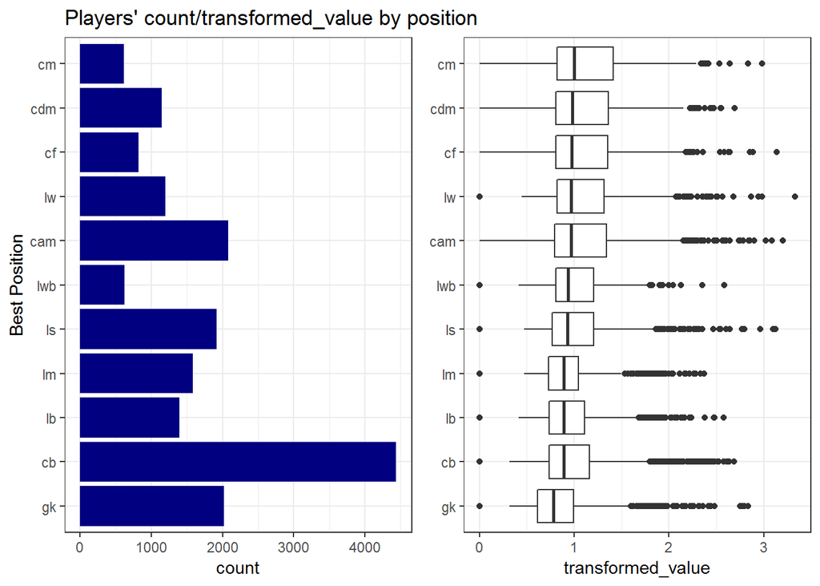

```r
pos_box = data %>%
mutate(best_pos = fct_reorder(best_pos, transformed_value)) %>%
ggplot(aes(x = best_pos, y = transformed_value)) +
geom_boxplot() +
theme(legend.position = "bottom") +
labs(x = NULL) +
coord_flip() + theme(axis.text.x = element_text(face = "plain", color = "black", size = 8)) + theme_bw()

pos_hist = data %>%
mutate(best_pos = fct_reorder(best_pos, transformed_value)) %>%
ggplot(aes(x = best_pos)) +
geom_bar(fill = "navy") + labs(title = "Players' count/transformed_value by position", x = "Best Position") +
    coord_flip() + theme(axis.text.x = element_text(face = "plain", color = "black", size = 8)) + theme_bw()

pos_hist + pos_box
```

- nationality
- plot the situation for nations with the most number of players:

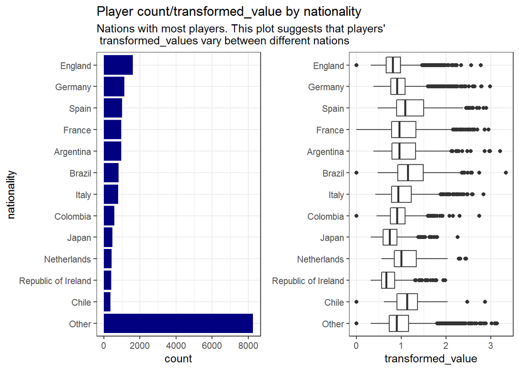

```r
nation_box = data %>%
    mutate(nationality = fct_lump(nationality, 12)) %>%
    mutate(nationality = fct_infreq(nationality)) %>%
    mutate(nationality = fct_rev(nationality)) %>%
    #move "Other" level to the last:
    mutate(nationality = fct_relevel(nationality, "Other", after = 0)) %>%
    ggplot(aes(x = nationality, y = transformed_value)) +
geom_boxplot() +
theme(legend.position = "bottom") +
labs( x = NULL) +
coord_flip() + theme(axis.text.x = element_text(face = "plain", color = "black", size = 8)) + theme_bw()

nation_hist = data %>%
    #If focus on most common nations:
    mutate(nationality = fct_lump(nationality, 12)) %>% #nations that have fewer players will be denoted as "Other"
    mutate(nationality = fct_infreq(nationality)) %>%
    mutate(nationality = fct_rev(nationality)) %>%
    #move "Other" level to the last:
    mutate(nationality = fct_relevel(nationality, "Other", after = 0)) %>%
    ggplot(aes(x = nationality)) +
    geom_bar(fill = "navy") +
    theme(legend.position = "bottom") +
    labs(title = "Player count/transformed_value by nationality", subtitle = "Nations with most players. This plot suggests that players' \n transformed_values vary between different nations") +
    coord_flip() + theme(axis.text.x = element_text(face = "plain", color = "black", size = 8))  +
    theme_bw()

nation_hist + nation_box
```

- plot the nations with highest players’ transformed_values:

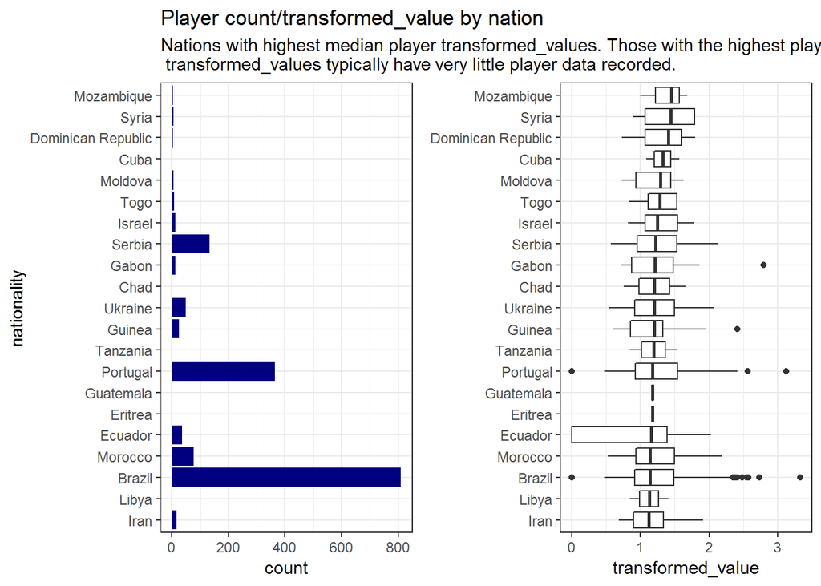

```r
nation_box = data %>%
    group_by(nationality) %>%
    mutate(med_by_nation = median(transformed_value)) %>%
    ungroup() %>%
    mutate(nationality = fct_reorder(nationality, med_by_nation)) %>%
    filter(as.integer(nationality) >= 145) %>%  #get the nations that have the largest median player transformed_values
    ggplot(aes(x = nationality, y = transformed_value)) +
    geom_boxplot() +
    theme(legend.position = "bottom") +
    labs( x = NULL) +
    coord_flip() + theme(axis.text.x = element_text(face = "plain", color = "black", size = 8)) + theme_bw()

nation_hist = data %>%
    group_by(nationality) %>%
    mutate(med_by_nation = median(transformed_value)) %>%
    ungroup() %>%
    mutate(nationality = fct_reorder(nationality, med_by_nation)) %>%
    filter(as.integer(nationality) >= 145) %>%  #get the nations that have the largest median player transformed_values
    ggplot(aes(x = nationality)) +
    geom_bar(fill = "navy") +
    theme(legend.position = "bottom") +
    labs(title = "Player count/transformed_value by nation", subtitle = "Nations with highest median player transformed_values. Those with the highest player\n transformed_values typically have very little player data recorded.") +
    coord_flip() + theme(axis.text.x = element_text(face = "plain", color = "black", size = 8))  + theme_bw()

nation_hist + nation_box
```

- club
- clubs that have the largest number of players

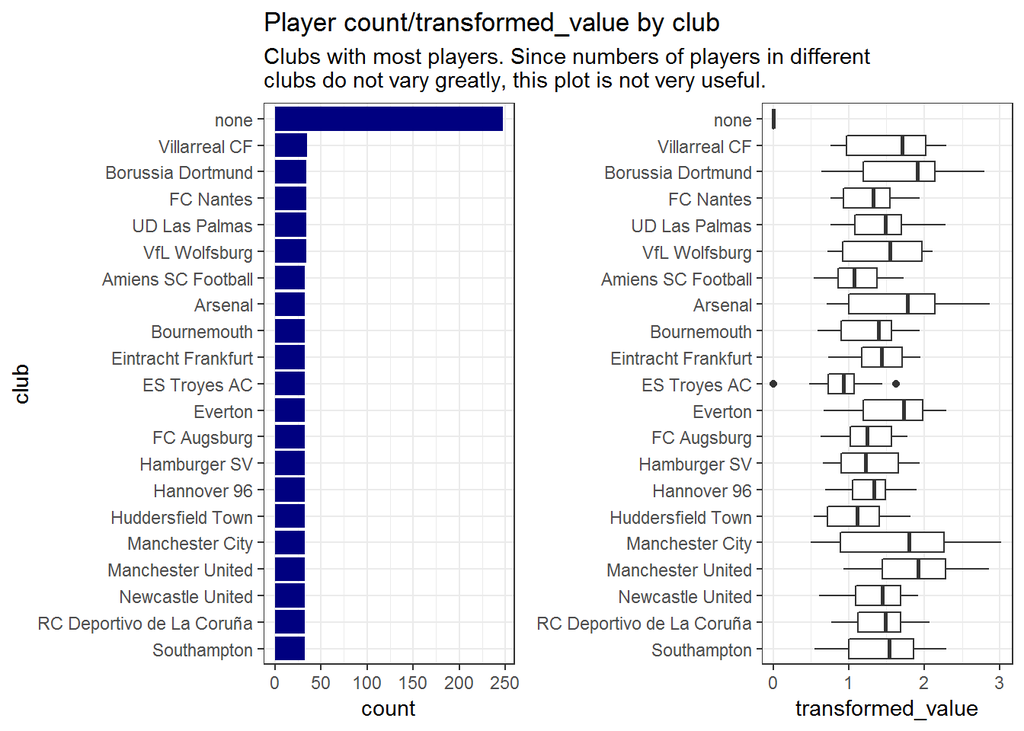

```r
club_box = data %>%
    mutate(club = fct_lump(club, 12)) %>%
    mutate(club = fct_infreq(club)) %>%
    mutate(club = fct_rev(club)) %>%
    #move "Other" level to the last:
    filter(club != "Other") %>%
    ggplot(aes(x = club, y = transformed_value)) +
geom_boxplot() +
theme(legend.position = "bottom") +
labs( x = NULL) +
coord_flip() + theme(axis.text.x = element_text(face = "plain", color = "black", size = 8)) + theme_bw()

club_hist = data %>%
    mutate(club = fct_lump(club, 12)) %>%
    mutate(club = fct_infreq(club)) %>%
    mutate(club = fct_rev(club)) %>%
    #move "Other" level to the last:
    filter(club != "Other") %>%
    ggplot(aes(x = club)) +
    geom_bar(fill = "navy") +
    theme(legend.position = "bottom") +
    labs(title = "Player count/transformed_value by club", subtitle = "Clubs with most players. Since numbers of players in different\nclubs do not vary greatly, this plot is not very useful.") +
    coord_flip() + theme(axis.text.x = element_text(face = "plain", color = "black", size = 8))  +
    theme_bw()

club_hist + club_box
```

- clubs that have the highest player median transformed_values

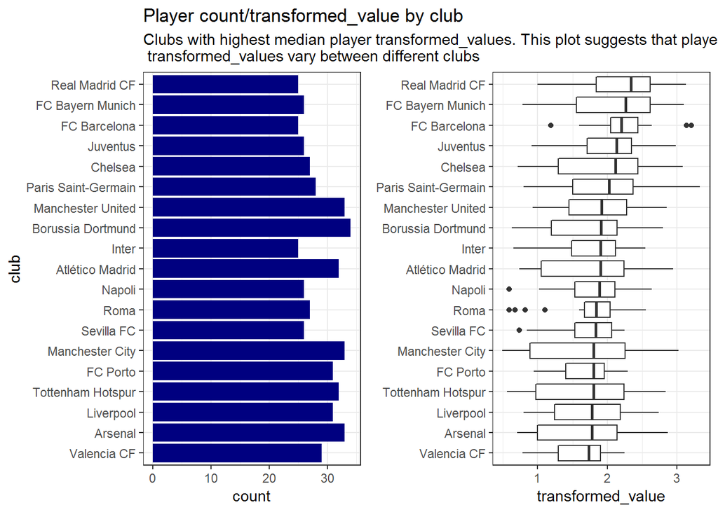

```r
club_box = data %>%
    group_by(club) %>%
    mutate(med_by_club = median(transformed_value)) %>%
    ungroup() %>%
    mutate(club = fct_reorder(club, med_by_club)) %>%
    filter(as.integer(club) >= 630) %>%  #get the clubs that have the highest median transformed_values
    ggplot(aes(x = club, y = transformed_value)) +
    geom_boxplot() +
    theme(legend.position = "bottom") +
    labs( x = NULL) +
    coord_flip() + theme(axis.text.x = element_text(face = "plain", color = "black", size = 8))  + theme_bw()

club_hist = data %>%
    group_by(club) %>%
    mutate(med_by_club = median(transformed_value)) %>%
    ungroup() %>%
    mutate(club = fct_reorder(club, med_by_club)) %>%
    filter(as.integer(club) >= 630) %>%  #get the clubs that have the highest median transformed_values
    ggplot(aes(x = club)) +
    geom_bar(fill = "navy") +
    theme(legend.position = "bottom") +
    labs(title = "Player count/transformed_value by club", subtitle = "Clubs with highest median player transformed_values. This plot suggests that players' \n transformed_values vary between different clubs") +
    coord_flip() + theme(axis.text.x = element_text(face = "plain", color = "black", size = 8))  + theme_bw()

club_hist + club_box
```

### for int/num variables

```r
# matrix of predictors
data_num  = data %>%
    keep(is.numeric) %>%
    select_if(~ !any(is.na(.))) %>%
    select(-transformed_value)

#x =  model.matrix(transformed_value~.,data_num)[,-1]
# vector of response
y <- data$transformed_value

featurePlot(data_num,
y,
plot = "scatter",
span = .5,
labels = c("Predictors","Y"),
type = "p",
layout = c(4, 10))
```

[figure not shown]

## Split the data set into training and testing data

```r
trRows = createDataPartition(data$transformed_value, p = .75, list = FALSE)
train = data[trRows,] %>% write_csv("..\\exploratory analysis\\train.csv")
test = data[-trRows,] %>% write_csv("..\\exploratory analysis\\test.csv")
```